# B8441 Hil family PF11765 domain evolution

Bin He

2022-07-07 Updated 15 September, 2022

```r
suppressPackageStartupMessages(require(tidyverse))
suppressPackageStartupMessages(require(cowplot))
suppressPackageStartupMessages(require(ggtext))
suppressPackageStartupMessages(require(ggtree))
suppressPackageStartupMessages(require(treeio))
```

# Goal

- Infer forces of natural selection acting on the PF11765 (NTD) among the Hil homologs in *C. auris*, B8441 strain.
- Differences between this and the previous MDR-PF11765-evolution analysis include
  1. Inclusion of an outgroup homolog from *M. bicuspidata* to root the domain tree.
  2. Apply PAML on part of the domain alignment that is inferred to be non-recombining by [GARD](https://datamonkey.org)

# Approach

Use PAML to estimate the branch length and omega values for the different branches in the PF11765 tree. If initial results suggest different rates / constraints among the branches, move on to perform formal hypotheses testing.

To avoid making mistakes in manually writing the control files and copying values from the result files to a spreadsheet, I learned to use Biopython’s PAML interface to set up a codeml object and write the settings to a control file as well as read the results.

# GARD

See `../output/gard/README.md` and other notes in this folder for details on how I generated the partitioned alignment and the tree for each of them.

```r
p1.freeR.cf2 <- read.codeml_mlc("../output/paml/B8441-OG-part/p1-414/branch-freer-cf2/mlc") %>% root(outgroup = "OG")
p1.oneR.cf2 <- read.codeml_mlc("../output/paml/B8441-OG-part/p1-414/branch-1r-cf2/mlc") %>% root(outgroup = "OG")
p1.freeR.cf1 <- read.codeml_mlc("../output/paml/B8441-OG-part/p1-414/branch-freer-cf1/mlc") %>% root(outgroup = "OG")
p1.oneR.cf1 <- read.codeml_mlc("../output/paml/B8441-OG-part/p1-414/branch-1r-cf1/mlc") %>% root(outgroup = "OG")
```

Plot the tree with omega ratios labeled for branches with high dN/dS

```r
p.cf2 <- ggtree(p1.freeR.cf2, aes(color = dN_vs_dS), size = 1, branch.length = 'none') +
  #geom_rootedge(rootedge = 0.1) +
  geom_nodelab(hjust = -0.2, size = 3, color = "black") +
  geom_tiplab(size = 6, hjust = -0.5, color = 1) +
  xlim(0, 5.6) +
#  geom_text(data = td_filter(dN_vs_dS > 1),
#            aes(x = branch, label = paste0("dN/dS>>1")),
#            vjust = 1.5, size = 4) +
#  geom_text(data = td_filter(dN_vs_dS > 1),
#            aes(x = branch, label = paste0("dN = ", round(dN, 2), "\n", "dS = ", round(dS, 2))),
#            vjust = 1.2, lineheight = 0.8, size = 4) +
  geom_richtext(data = td_filter(node == 12), aes(x = branch, label = "FG"),
                fill = NA, label.color = NA, vjust = 0, size = 6, color = "red") +
  geom_richtext(data = td_filter(node == 11), aes(x = branch, label = "FG"),
                fill = NA, label.color = NA, vjust = 0, size = 6, color = "red") +
  geom_richtext(data = td_filter(node == 16), aes(x = branch, label = "FG"),
                fill = NA, label.color = NA, vjust = 0, size = 6, color = "red") +
  scale_color_continuous(name='dN/dS', trans = "pseudolog",
                         #limits=c(0, 10), breaks = seq(0, 3, 1), labels = c("0", "1", "2", ">3"),
                         low='darkgreen', high="darkviolet") +
  theme(legend.position = c(0.1,0.8), legend.text = element_text(size = 12),
        legend.title = element_text(size = 14))
```

```
Error in get(as.character(FUN), mode = "function", envir = envir) :
  object 'pseudolog_trans' of mode 'function' was not found
```

```r
p.cf1 <- ggtree(p1.freeR.cf1, aes(color = dN_vs_dS), size = 1, branch.length = 'none') +
  #geom_rootedge(rootedge = 0.1) +
  geom_nodelab(hjust = -0.2, size = 3, color = "black") +
  geom_tiplab(size = 6, hjust = -0.5, color = 1) +
  xlim(0, 5.6) +
#  geom_text(data = td_filter(dN_vs_dS > 1),
#            aes(x = branch, label = paste0("dN/dS>>1")),
#            vjust = 1.5, size = 4) +
#  geom_text(data = td_filter(dN_vs_dS > 1.5),
#            aes(x = branch, label = paste0("dN = ", signif(dN, 2), "\n", "dS = ", signif(dS, 2))),
#            vjust = 1.2, lineheight = 0.8, size = 4) +
  geom_richtext(data = td_filter(node == 12), aes(x = branch, label = "FG"),
                fill = NA, label.color = NA, vjust = 0, size = 6, color = "red") +
  geom_richtext(data = td_filter(node == 13), aes(x = branch, label = "FG"),
                fill = NA, label.color = NA, vjust = 0, size = 6, color = "red") +
  geom_richtext(data = td_filter(node == 16), aes(x = branch, label = "FG"),
                fill = NA, label.color = NA, vjust = 0, size = 6, color = "red") +
  scale_color_continuous(name='dN/dS',
                         limits=c(0, 1.5), breaks = seq(0, 1.5, 0.5), labels = c("0", "0.5", "1", ">1.5"),
                         oob=scales::squish, low='darkgreen', high="darkviolet") +
  theme(legend.position = c(0.1,0.8), legend.text = element_text(size = 12),
        legend.title = element_text(size = 14))
#ggsave("../output/figure/20220122-MDR-PF11765-freeR-anno-tree.png", width = 7, height = 4.5)
```

[figure not shown]

```r
plot_grid(p.cf1 + labs(title = "CodonFreq = 1"), p.cf2 + labs(title = "CodonFreq = 2"), nrow = 1)
```

```r
ggsave(paste0("../output/figure/", gsub("-", "", Sys.Date()),"-B8441-OG-p1-414-branch-freer-tree.png"), width = 10, height = 5)
```

> In my previous analysis where I found that how I specify the codonfreq parameter has a profound effect on the branch lengths estimates. In particular, `CodonFreq=2` (F3x4) results in very large dS estimates and identified different branches as having elevated dN/dS than `CodonFreq=0/1` did. Here focusing on the 1-414 fragment, I found the inconsistencies between `CodonFreq=2` and `CodonFreq=1` are less significant. A few branches were identified as having large ω by both analyses:
> - 12..16 (ancestral to Hil6 and Hil8)
> - 11..12 (ancestral to Hil1, 2, 3, 4, 6 and 8)

Note that `CodonFreq=2` results in a highly non-ultrametric tree

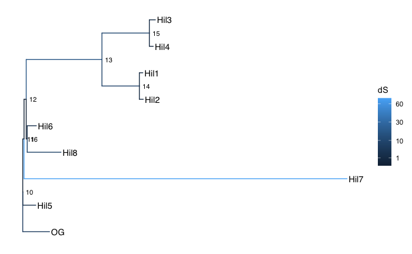

```r
ggtree(p1.freeR.cf2, aes(color = dS)) +
  scale_color_gradient(trans = "sqrt", breaks = c(0, 1, 10, 30, 60)) +
  geom_tiplab(color = 1) + geom_nodelab(color = 1, size = 3, hjust = -.2)
```

This is not the case for `CodonFreq=1`

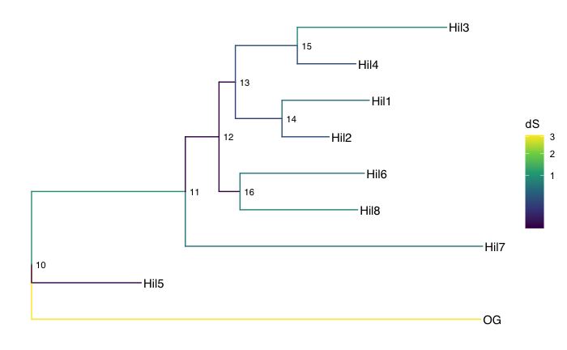

```r
ggtree(p1.freeR.cf1, aes(color = dS)) +
  scale_color_viridis_c(option = "D", trans = "sqrt") +
  geom_tiplab(color = 1) + geom_nodelab(color = 1, size = 3, hjust = -.2)
```

# Partition 697-981

## One ratio vs free ratio

Read in the tree files with PAML results

```r
p2.freeR.cf2 <- read.codeml_mlc("../output/paml/B8441-OG-part/p697-981/branch-freer-cf2/mlc") %>% root(outgroup = "OG")
p2.oneR.cf2 <- read.codeml_mlc("../output/paml/B8441-OG-part/p697-981/branch-1r-cf2/mlc") %>% root(outgroup = "OG")
p2.freeR.cf1 <- read.codeml_mlc("../output/paml/B8441-OG-part/p697-981/branch-freer-cf1/mlc") %>% root(outgroup = "OG")
p2.oneR.cf1 <- read.codeml_mlc("../output/paml/B8441-OG-part/p697-981/branch-1r-cf1/mlc") %>% root(outgroup = "OG")
```

Plot the tree with omega ratios labeled for branches with high dN/dS

[figure not shown]

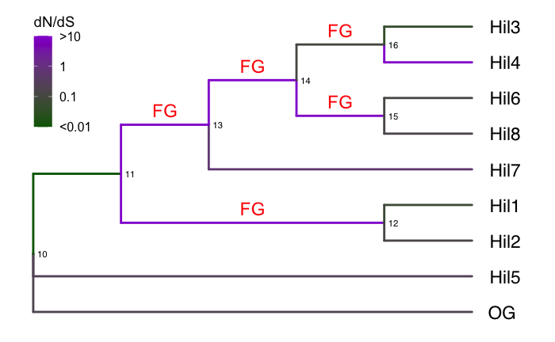

```r
p.cf1 <- ggtree(p2.freeR.cf1, aes(color = dN_vs_dS), size = 1, branch.length = 'none') +
  geom_nodelab(hjust = -0.2, size = 3, color = "black") +
  geom_tiplab(size = 6, hjust = -0.5, color = 1) +
  xlim(0, 5.6) +
  geom_richtext(data = td_filter(node %in% c(16, 12, 13, 14, 15)), aes(x = branch, label = "FG"),
                fill = NA, label.color = NA, vjust = 0, size = 6, color = "red") +
  scale_color_continuous(name='dN/dS', trans = "log10", limits=c(0.01, 10),
                         breaks = c(0.01, 0.1, 1, 10), labels = c("<0.01", "0.1", "1", ">10"),
                         oob=scales::squish, low='darkgreen', high="darkviolet") +
  theme(legend.position = c(0.1,0.8), legend.text = element_text(size = 12),
        legend.title = element_text(size = 14))
p.cf1
```

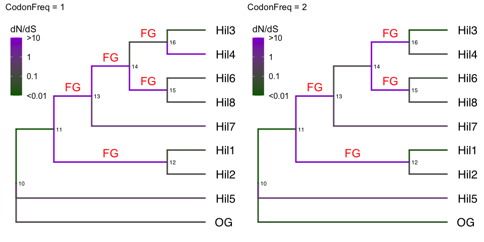

```r
plot_grid(p.cf1 + labs(title = "CodonFreq = 1"), p.cf2 + labs(title = "CodonFreq = 2"), nrow = 1)
```

```r
ggsave(paste0("../output/figure/", gsub("-", "", Sys.Date()),"-B8441-OG-p697-981-branch-freer-tree.png"), width = 10, height = 5)
```